# Assignment3

#### Q1:

#### Read in the peanuts_reviews.csv Download peanuts_reviews.csv dataset. How many reviews are there? What percentage of the reviews are positive (4 or 5) and what percentage are negative (1 or 2) reviews?

#### A1:

```python
import pandas as pd
nutpea = pd.read_csv("peanuts_reviews.csv")
```

#### Total Reviews

```python
num_reviews = len(nutpea)
print(num_reviews)
```

```
493
```

#### Positive Reviews

```python
pos_review = nutpea[nutpea["rating"].isin([4, 5])].shape[0]

pos_pct = (pos_review/num_reviews) * 100
```

```python
print(f"Positive (4 - 5 rating): {pos_pct:.2f}%")
```

```
Positive (4 - 5 rating): 67.75%
```

#### Negative Reviews

```python
neg_review = nutpea[nutpea["rating"].isin([1, 2])].shape[0]

neg_pct = (neg_review/num_reviews) * 100
```

```python
print(f"Negative (1 - 2 rating): {neg_pct:.2f}%")
```

```
Negative (1 - 2 rating): 32.25%
```

#### Q2:

#### Generate a two wordclouds: one for good reviews and one for bad reviews. Provide a short (2-3 sentences) explanation of what the wordcloud does and any noteworthy insights we can see.

#### A2:

```python
import matplotlib.pyplot as plt
from wordcloud import WordCloud
from wordcloud import STOPWORDS
```

```
<function matplotlib.pyplot.show(close=None, block=None)>
```

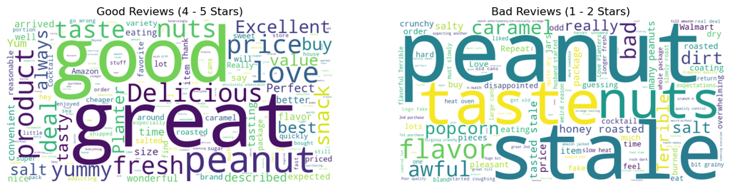

```python
nutpea = nutpea.dropna(subset=['text'])

pos_review = nutpea[nutpea['rating'].isin([4, 5])]
neg_review = nutpea[nutpea['rating'].isin([1, 2])]

pos_text = " ".join(pos_review['text'])
neg_text = " ".join(neg_review['text'])

custom_stopwords = set(STOPWORDS).union({
    'the', 'and', 'it', 'to', 'is', 'was', 'for', 'of'})

pos_wc = WordCloud(width = 800, height = 400, background_color = 'white', stopwords = custom_stopwords).generate(pos_text)
neg_wc = WordCloud(width = 800, height = 400, background_color = 'white', stopwords = custom_stopwords).generate(neg_text)

plt.figure(figsize = (14,6))

plt.subplot(1, 2, 1)
plt.imshow(pos_wc)
plt.axis('off')
plt.title("Good Reviews (4 - 5 Stars)")

plt.subplot(1, 2, 2)
plt.imshow(neg_wc)
plt.axis('off')
plt.title("Bad Reviews (1 - 2 Stars)")

plt.show
```

#### The wordcloud visualizes the most frequently used words in the set of reviews from Nutpea, Inc., with larger words appearing more often in the text. The positive review cloud highlights what customers consistently value (e.g., quality, service, experience). The negative review cloud reveals common pain points or complaints. This makes it easy to identify themes to reinforce or address without reading every individual review.

#### Q3:

#### Using scikit-learn's CountVectorizer, what are top five most frequent single words (unigrams) used in positive reviews? What are top five most frequent single words used in negative reviews? (For questions 3-5, exclude the default English stopwords from scikit-learn's vectorizer)

#### A3:

```python
from sklearn.feature_extraction.text import CountVectorizer

nutpea = nutpea.dropna(subset = ['text'])

pos_review = nutpea[nutpea['rating'].isin([4, 5])]
neg_review = nutpea[nutpea['rating'].isin([1, 2])]

vectorizer = CountVectorizer(stop_words = 'english')

x_pos = vectorizer.fit_transform(pos_review['text'])
pos_word_count = x_pos.sum(axis = 0)
pos_freq = [(word, pos_word_count[0,idx])
            for word, idx in vectorizer.vocabulary_.items()]

top_pos = sorted(pos_freq, key = lambda x: x[1], reverse = True)[:5]

print("Top 5 Words in Positive Reviews:")
for word, count in top_pos:
    print(f"{word}: {count}")
```

```
Top 5 Words in Positive Reviews:
great: 88
good: 84
peanuts: 46
love: 26
product: 24
```

```python
x_neg = vectorizer.fit_transform(neg_review['text'])
neg_word_count = x_neg.sum(axis = 0)
neg_freq = [(word, neg_word_count[0,idx])
            for word, idx in vectorizer.vocabulary_.items()]

top_neg = sorted(neg_freq, key = lambda x: x[1], reverse = True)[:5]

print("Top 5 Words in Negative Reviews:")
for word, count in top_neg:
    print(f"{word}: {count}")
```

```
Top 5 Words in Negative Reviews:
peanuts: 38
stale: 37
like: 28
taste: 24
nuts: 20
```

#### Q4:

#### What are top five most frequent two word phrases used in positive reviews? What are top five most frequent two word phrases used in negative reviews?

#### A4:

```python
ngram_range = (2, 2)

nutpea = nutpea.dropna(subset = ['text'])

pos_review = nutpea[nutpea['rating'].isin([4, 5])]
neg_review = nutpea[nutpea['rating'].isin([1, 2])]

def get_top_bigrams(text_series, n = 5):
    vectorizer = CountVectorizer(stop_words = 'english', ngram_range = (2,2))
    x = vectorizer.fit_transform(text_series)

    counts = x.sum(axis = 0).A1
    phrases = vectorizer.get_feature_names_out()

    freq_df = pd.DataFrame({
        'phrase': phrases,
        'count': counts
    })

    return freq_df.sort_values(by = 'count', ascending = False).head(n)

top_pos_bigrams = get_top_bigrams(pos_review['text'])
top_neg_bigrams = get_top_bigrams(neg_review['text'])

print("Top 5 Bigrams in Positive Reviews: \n")
print(top_pos_bigrams)

print("\nTop 5 Bigrams in Negative Reviews:\n")
print(top_neg_bigrams)
```

```
Top 5 Bigrams in Positive Reviews:

            phrase  count
222    great price      9
184     good price      7
232    great value      7
223  great product      6
186   good product      6

Top 5 Bigrams in Negative Reviews:

             phrase  count
71        like dirt      8
152  terrible taste      8
58    honey roasted      7
148    tasted stale      7
80      love showed      4
```

#### Q5:

#### Create two plots: one with the 10 most common two word phrases used in negative reviews and their frequencies (order the phrases by frequency) and one with the 10 most common two word phrases used in positive reviews and their frequencies (order the phrases by frequency). Write a short explanation (8-10 sentences) of what insights the company can take away from the plots and answer at least the following questions:

- What aspects of the product are positive reviewers mentioning? What are the negative reviewers mentioning?
- Do the results indicate indicate that unsatisfied customers are most unhappy with product prices, quality, variety, or something else?
- What is one actionable insight that a manager should takeaway from your analysis?

#### A5:

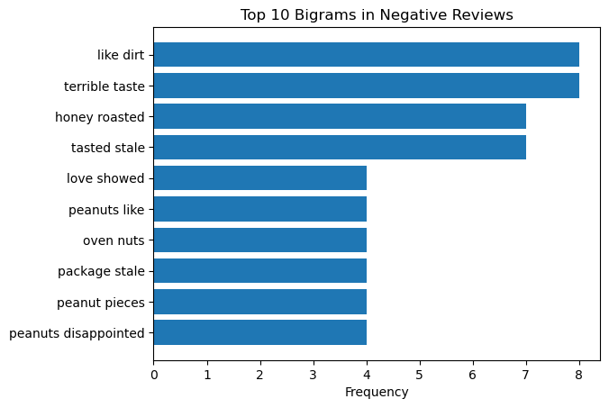

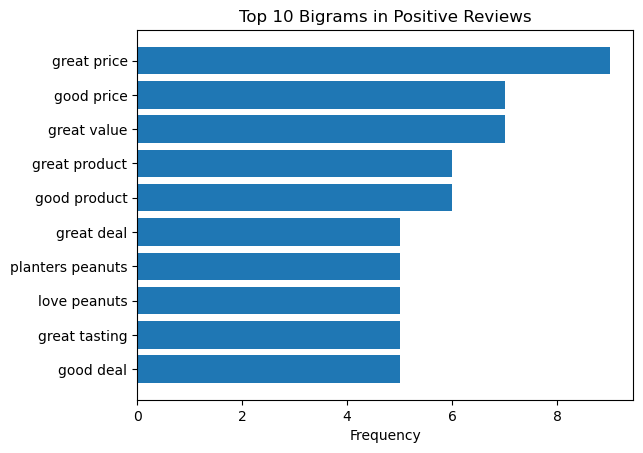

```python
nutpea = nutpea.dropna(subset = ['text'])

pos_review = nutpea[nutpea['rating'].isin([4, 5])]
neg_review = nutpea[nutpea['rating'].isin([1, 2])]

def get_top_bigrams(text_series, n = 10):
    vectorizer = CountVectorizer(stop_words = 'english', ngram_range = (2, 2))
    x = vectorizer.fit_transform(text_series)

    counts = x.sum(axis = 0).A1
    phrases = vectorizer.get_feature_names_out()

    freq_df = pd.DataFrame({
        'phrase': phrases,
        'count': counts
    })

    return freq_df.sort_values(by = 'count', ascending = False).head(n)

top_pos = get_top_bigrams(pos_review['text'], 10)
top_neg = get_top_bigrams(neg_review['text'], 10)

plt.figure()
plt.barh(top_neg['phrase'], top_neg['count'])
plt.xlabel("Frequency")
plt.title("Top 10 Bigrams in Negative Reviews")
plt.gca().invert_yaxis()
plt.show()

plt.figure()
plt.barh(top_pos['phrase'], top_pos['count'])
plt.xlabel("Frequency")
plt.title("Top 10 Bigrams in Positive Reviews")
plt.gca().invert_yaxis()
plt.show()
```

#### The aspects mentioned by positive reviewers of the product are 'great price', 'good price', 'great value', 'great product', 'good product', 'great deal', 'planters peanuts', 'love peanuts', 'great tasting', 'good deal'. The aspects mentioned by negative reviewers of the product are 'like dirt', 'terrible taste', 'honey roasted', 'tasted stale', 'love showed', 'peanuts like', 'oven nuts', 'package stale', 'peanut pieces', 'peanuts disappointed'. The results indicate that the unsatisfied customeers are most unhappy with the quality / taste of the product. However the positive reviewers are most satisfied with the price / value of the product. One actionable insight is that some R&D should be done on the taste of the flavors that were purchased by the consumer that noted that being a factor of dissatisfaction. This will allow them to improve the quality of the product and increase satisfaction in the notable places.

#### Q6:

#### Create a user-defined function that takes a dataframe, instantiates a vectorizer with a custom n-gram range with minimum and maximum set to 1 as default but that can be adjusted as an input to the function, that vectorizes that text column of the dataframe, converts the sparse arrays to dense arrays, sums the frequencies of the terms, sorts the results by the count and keeps only the top n number of results where n is a parameter in the function that is 10 by default but can be adjusted, and returns a plot of the results (using a visualization package of your choice). The function should take four arguments.

#### A6:

```python
def plot_top_terms(nutpea, text, ngram_range = (1, 1), top_n = 10):
    nutpea = nutpea.dropna(subset = [text])

    vectorizer = CountVectorizer(stop_words = 'english', ngram_range = ngram_range)

    x = vectorizer.fit_transform(nutpea[text])

    dense_array = x.toarray()

    term_counts = dense_array.sum(axis = 0)

    terms = vectorizer.get_feature_names_out()

    freq_df = pd.DataFrame({
        'term': terms,
        'count': term_counts
    })

    freq_df = freq_df.sort_values(by = 'count', ascending = False).head(top_n)

    plt.figure(figsize = (10, 6))
    plt.barh(freq_df['term'], freq_df['count'])
    plt.xlabel("Frequency")
    plt.ylabel("Term")
    plt.title(f"Top {top_n} Terms")
    plt.gca().invert_yaxis()
    plt.show()

    return freq_df
```

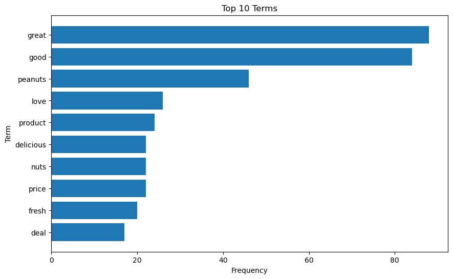

|  | term | count |
| --- | --- | --- |
| 121 | great | 88 |
| 114 | good | 84 |
| 195 | peanuts | 46 |
| 163 | love | 26 |
| 209 | product | 24 |
| 71 | delicious | 22 |
| 178 | nuts | 22 |
| 205 | price | 22 |
| 107 | fresh | 20 |
| 67 | deal | 17 |

```python
plot_top_terms(pos_review, 'text')
```

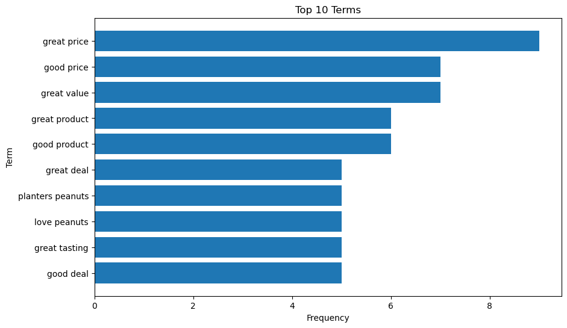

|  | term | count |
| --- | --- | --- |
| 222 | great price | 9 |
| 184 | good price | 7 |
| 232 | great value | 7 |
| 223 | great product | 6 |
| 186 | good product | 6 |
| 207 | great deal | 5 |
| 367 | planters peanuts | 5 |
| 298 | love peanuts | 5 |
| 231 | great tasting | 5 |
| 174 | good deal | 5 |

```python
plot_top_terms(pos_review, 'text', ngram_range=(2, 2), top_n=10)
```

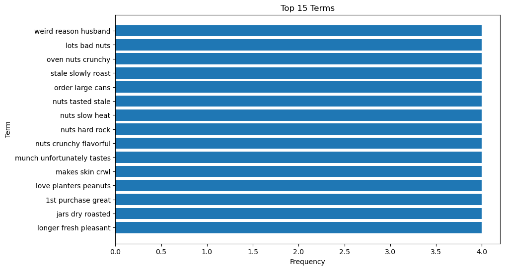

|  | term | count |
| --- | --- | --- |
| 125 | weird reason husband | 4 |
| 64 | lots bad nuts | 4 |
| 74 | oven nuts crunchy | 4 |
| 114 | stale slowly roast | 4 |
| 72 | order large cans | 4 |
| 71 | nuts tasted stale | 4 |
| 70 | nuts slow heat | 4 |
| 69 | nuts hard rock | 4 |
| 68 | nuts crunchy flavorful | 4 |
| 67 | munch unfortunately tastes | 4 |
| 66 | makes skin crwl | 4 |
| 65 | love planters peanuts | 4 |
| 1 | 1st purchase great | 4 |
| 51 | jars dry roasted | 4 |
| 62 | longer fresh pleasant | 4 |

```python
plot_top_terms(neg_review, 'text', ngram_range=(3, 3), top_n=15)
```

#### Q7:

#### Use the function you created in question 6 to generate a plot with the seven most frequent three-word phrases used in positive reviews of the peanuts with the phrases on the y-axis and the frequencies on the x-axis, ordered in descending order of frequencies from top to bottom. Note: this should be done in one line of code.

#### A7:

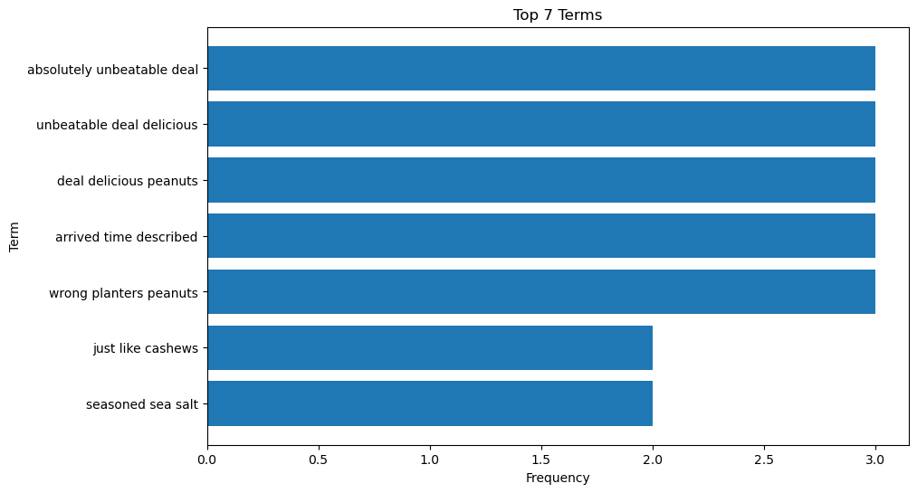

|  | term | count |
| --- | --- | --- |
| 2 | absolutely unbeatable deal | 3 |
| 383 | unbeatable deal delicious | 3 |
| 65 | deal delicious peanuts | 3 |
| 9 | arrived time described | 3 |
| 401 | wrong planters peanuts | 3 |
| 204 | just like cashews | 2 |
| 338 | seasoned sea salt | 2 |

```python
plot_top_terms(pos_review, 'text', ngram_range=(3, 3), top_n=7)
```